# Reproducible Research: Peer Assessment 1

## Loading and preprocessing the data

### First

We start by charge the libaries that we will use

```r
library(dplyr)
```

```r
library(ggplot2)
```

### second

We loading the file and turning it into a df table to facilitate its processing and see the first rows.

```r
activity<- read.csv("/Users/johnsprockel/Documents/GitHub/ProgrammingAssignment2/activity.csv")
activity<- tbl_df(activity)
head(activity)
```

```
## # A tibble: 6 x 3
##   steps date       interval
##   <int> <chr>         <int>
## 1    NA 2012-10-01        0
## 2    NA 2012-10-01        5
## 3    NA 2012-10-01       10
## 4    NA 2012-10-01       15
## 5    NA 2012-10-01       20
## 6    NA 2012-10-01       25
```

### Third

We review the summary of the file finding that:

-Its length is 17568 data

-has 2304 NA’s

Now we proceed to eliminate NA’s

```r
summary (activity)
```

```
##      steps            date              interval
##  Min.   :  0.00   Length:17568       Min.   :   0.0
##  1st Qu.:  0.00   Class :character   1st Qu.: 588.8
##  Median :  0.00   Mode  :character   Median :1177.5
##  Mean   : 37.38                      Mean   :1177.5
##  3rd Qu.: 12.00                      3rd Qu.:1766.2
##  Max.   :806.00                      Max.   :2355.0
##  NA's   :2304
```

```r
activity<- activity[!is.na(activity$steps),]
```

-the minimum value of steps is 0 and the maximum is 806, its mean is 37 and median is 0

-the minimum value of interval is 0 and the maximum is 2355, its mean and median are 1177.5.

### Fourth

We proceed to change the date variable to said format to obtain the tidy data.

```r
activity$date<- as.Date(as.character(activity$date))
summary(activity)
```

```
##      steps             date               interval
##  Min.   :  0.00   Min.   :2012-10-02   Min.   :   0.0
##  1st Qu.:  0.00   1st Qu.:2012-10-16   1st Qu.: 588.8
##  Median :  0.00   Median :2012-10-29   Median :1177.5
##  Mean   : 37.38   Mean   :2012-10-30   Mean   :1177.5
##  3rd Qu.: 12.00   3rd Qu.:2012-11-16   3rd Qu.:1766.2
##  Max.   :806.00   Max.   :2012-11-29   Max.   :2355.0
```

## What is mean total number of steps taken per day?

Initially the table is grouped by date, then we generate a new table with the sum, mean and median of steps for each day.

```r
activity<- group_by(activity, date)
x<- summarise(activity, sum= sum(steps), mean = mean (steps), median = median(steps))
x
```

```
## # A tibble: 53 x 4
##    date         sum   mean median
##    <date>     <int>  <dbl>  <dbl>
##  1 2012-10-02   126  0.438      0
##  2 2012-10-03 11352 39.4        0
##  3 2012-10-04 12116 42.1        0
##  4 2012-10-05 13294 46.2        0
##  5 2012-10-06 15420 53.5        0
##  6 2012-10-07 11015 38.2        0
##  7 2012-10-09 12811 44.5        0
##  8 2012-10-10  9900 34.4        0
##  9 2012-10-11 10304 35.8        0
## 10 2012-10-12 17382 60.4        0
## # … with 43 more rows
```

The total steps of each day are plotted.

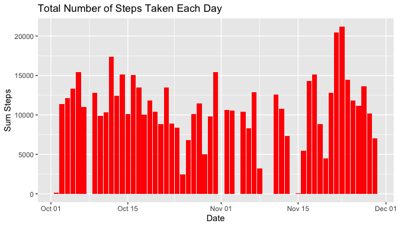

```r
g<-ggplot(x, aes(date, sum))
g+ geom_bar(stat="identity", fill = "red") +
  ggtitle("Total Number of Steps Taken Each Day") +
  xlab("Date") + ylab("Sum Steps")
```

The mean of total steps of each day are plotted.

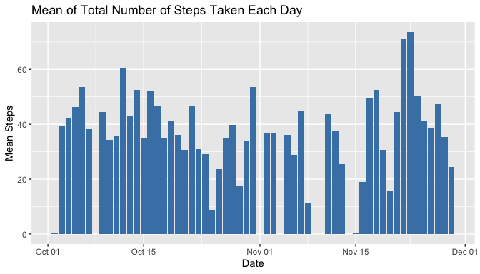

```r
g<-ggplot(x, aes(date, mean))
g+ geom_bar(stat="identity", fill = "steelblue") +
  ggtitle("Mean of Total Number of Steps Taken Each Day") +
  xlab("Date") + ylab("Mean Steps")
```

[figure not shown]

```r
g<-ggplot(x, aes(date, median))
g+ geom_bar(stat="identity", fill = "steelblue") +
  ggtitle("Median of Total Number of Steps Taken Each Day") +
  xlab("Date") + ylab("Median Steps")
```

Each day, the median was 0.

## What is the average daily activity pattern?

This is a time series plot of the average number of steps taken.

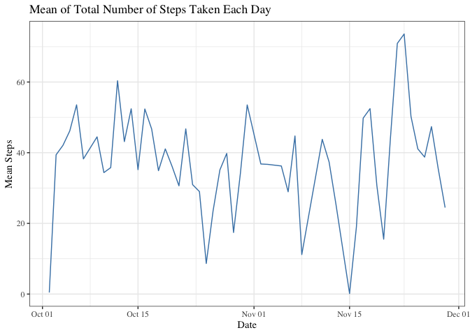

```r
g<-ggplot(x, aes(date, mean))
g+ geom_line(color = "steelblue") +
  ggtitle("Mean of Total Number of Steps Taken Each Day") +
  xlab("Date") + ylab("Mean Steps")+
  theme_bw(base_family = "Times")
```

Create an data table with steps and interval and grouped by interval, then calculate the mean for each interval.

```r
con<- cbind(activity$steps, activity$interval)
con<- as.data.frame(con)
con<- group_by(con, con[,2])

y<- summarise(con, mean = mean (V1))
colnames(y)<- c("steps", "interval")
y
```

[output not shown]

[figure not shown]

```r
g<-ggplot(y, aes(interval, steps))
g+ geom_line(color = "green") +
  ggtitle("Mean of Total Number of Steps Taken by Interval") +
  xlab("Interval") + ylab("Mean Steps")+
  theme_bw(base_family = "Times")
```

## Imputing missing values

We load the data again

```r
activity<- read.csv("/Users/johnsprockel/Documents/GitHub/ProgrammingAssignment2/activity.csv")
activity<- tbl_df(activity)

activity$date<- as.Date(as.character(activity$date))
str(activity$steps)
```

```
##  int [1:17568] NA NA NA NA NA NA NA NA NA NA ...
```

1. Calculate and report the total number of missing values in the dataset (i.e. the total number of rows with NAs).

There are 2304 NA’s

2. I decide to filling in all of the missing values in the data set by use the mean for that 5-minute interval.
3. Next, I create a new dataset that is equal to the original dataset but with the missing data filled in.

```r
tt<- activity %>%
  group_by(interval) %>%
    summarise(mean_steps = mean(steps, na.rm = TRUE))
for (i in 1:length(activity$steps)){
  if(is.na(activity$steps[i])){
    activity$steps[i]<- tt$mean_steps[match(activity$interval[i], tt$interval)]
  }
}
```

```r
activity<- group_by(activity, date)

x<- summarise(activity, sum= sum(steps), mean = mean (steps), median = median(steps))
x
```

```
## # A tibble: 61 x 4
##    date          sum   mean median
##    <date>      <dbl>  <dbl>  <dbl>
##  1 2012-10-01 10766. 37.4     34.1
##  2 2012-10-02   126   0.438    0
##  3 2012-10-03 11352  39.4      0
##  4 2012-10-04 12116  42.1      0
##  5 2012-10-05 13294  46.2      0
##  6 2012-10-06 15420  53.5      0
##  7 2012-10-07 11015  38.2      0
##  8 2012-10-08 10766. 37.4     34.1
##  9 2012-10-09 12811  44.5      0
## 10 2012-10-10  9900  34.4      0
## # … with 51 more rows
```

The total steps of each day are plotted.

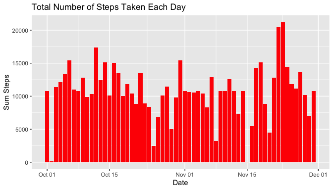

```r
g<-ggplot(x, aes(date, sum))
g+ geom_bar(stat="identity", fill = "red") +
  ggtitle("Total Number of Steps Taken Each Day") +
  xlab("Date") + ylab("Sum Steps")
```

The mean of total steps of each day are plotted.

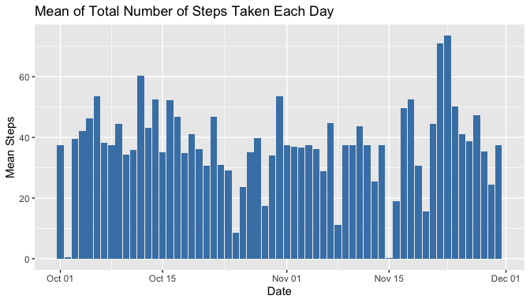

```r
g<-ggplot(x, aes(date, mean))
g+ geom_bar(stat="identity", fill = "steelblue") +
  ggtitle("Mean of Total Number of Steps Taken Each Day") +
  xlab("Date") + ylab("Mean Steps")
```

## Are there differences in activity patterns between weekdays and weekends?

Firts I create a new column with a factor variable in the dataset with the days of the week, then clasified in two levels – “weekday” and “weekend” indicating whether a given date is a weekday or weekend day.

```r
activity<- read.csv("/Users/johnsprockel/Documents/GitHub/ProgrammingAssignment2/activity.csv")
activity<- tbl_df(activity)
activity<- activity[!is.na(activity$steps),]
activity$date<- as.Date(as.character(activity$date))

activity<- mutate(activity, day= weekdays(activity$date))
activity$day<- gsub("Saturday", "Weekend", activity$day)
activity$day<- gsub("Sunday", "Weekend", activity$day)
activity$day<- gsub("Friday", "Weekday", activity$day)
activity$day<- gsub("Monday", "Weekday", activity$day)
activity$day<- gsub("Thursday", "Weekday", activity$day)
activity$day<- gsub("Tuesday", "Weekday", activity$day)
activity$day<- gsub("Wednesday", "Weekday", activity$day)
```

```r
WD<- cbind(unique (activity$interval), "Weekday", 0)
colnames(WD)<- c("interval", "day", "steps")
WD<- as.data.frame(WD)
WD[,1] <- as.numeric(WD[,1])
WD[,3] <- as.numeric(WD[,3])

WE<- cbind(unique (activity$interval), "Weekend", 0)
colnames(WE)<- c("interval", "day", "steps")
WE<- as.data.frame(WE)
WE[,1] <- as.numeric(WE[,1])
WE[,3] <- as.numeric(WE[,3])

for (i in 1:288){
  WD$steps[i]<- mean(activity$steps[activity$interval[]==WD$interval[i]] & activity$day[]== "Weekday")
  WE$steps[i]<- mean(activity$steps[activity$interval[]==WE$interval[i]] & activity$day[]== "Weekend")
}
head(WD)
```

```
##   interval     day      steps
## 1        0 Weekday 0.04160115
## 2        5 Weekday 0.01382338
## 3       10 Weekday 0.01382338
## 4       15 Weekday 0.01382338
## 5       20 Weekday 0.01388889
## 6       25 Weekday 0.05562107
```

```r
head(WE)
```

```
##   interval     day       steps
## 1        0 Weekend 0.015002621
## 2        5 Weekend 0.005044549
## 3       10 Weekend 0.005044549
## 4       15 Weekend 0.005044549
## 5       20 Weekend 0.004979036
## 6       25 Weekend 0.019850629
```

```r
db<- rbind(WD, WE)
str(db)
```

```
## 'data.frame':    576 obs. of  3 variables:
##  $ interval: num  0 5 10 15 20 25 30 35 40 45 ...
##  $ day     : chr  "Weekday" "Weekday" "Weekday" "Weekday" ...
##  $ steps   : num  0.0416 0.0138 0.0138 0.0138 0.0139 ...
```

We proceed to graph the relationship of the different steps by interval in weekdays and weekends.

[figure not shown]

```r
g<-ggplot(db, aes(interval, steps))
g+ geom_line(color = "steelblue") +
  ggtitle("Mean in Total Number of Steps Taken by Weekday") +
  xlab("Interval") + ylab("Sum Steps")+
  facet_grid(day~.)
```